# Big Data Project: Analysing Yelp Data

26 3 2021

## The Project

The Project we are about to present is an analysis of a YELP dataset that we found on kaggle.  
The basic idea is to conduct two different analysis:  
- The probability of being an elite user  
We assume that people giving low star reviews will less likely be elite users. For this we use a Uluru OLS method.  
- The most important factors for good restaurant reviews  
We try to predict the most important factors by using lasso and forward selection.

## Workflow

- Getting the data
- Analysis
- Results

## Getting the data

- Download the files
- *Problem 1: JSON unusable –> change into usable format*

## R Code to convert JSON into csv

- Vectorization of function to process JSON strings:

```r
jsonStrings<-as.list(readLines('yelp_academic_dataset_business.json'))
modifyObjects<-Vectorize(modifyObject, SIMPLIFY = F)
```

- Using the jsonlite::stream_in function:

```r
user<-stream_in(file('yelp_academic_dataset_user.json'), verbose = T)
```

## Getting the data

- Download the files
- Change into usable format
- *Filtering and cleaning*

## Filtering and cleaning

Problem 2: The data was still too big

1. Use efficient functions
2. Filter out and clean variables

## Using efficient functions

Benchmarking between different read in functions:

```r
results <- microbenchmark(
  'base::read.csv' = read.csv("CSVFiles/business.csv"),
  'readr::read_csv' = read_csv("CSVFiles/business.csv"),
  'vroom::vroom' = vroom("CSVFiles/business.csv"),
  'data.table::fread' = fread("CSVFiles/business.csv"),
  times = 25L
)
```

## Using efficient functions

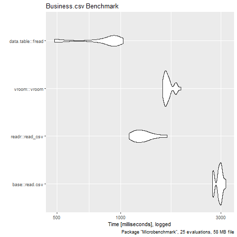

## Using efficient functions

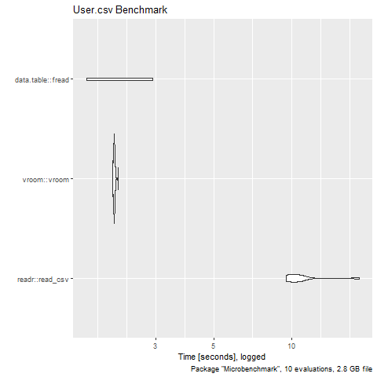

## Filter out and clean variables

1. business dataset:
- limited our observations to restaurants
- filtered out closed restaurants
- filtered out variables with >95% NA
- converted character variables to logical or factor
- used only variables with less than 20’000 NAs
- *final data set with 37 variables*

## Filter out and clean variables

1. user dataset:
- to save RAM, only read the 5 relevant variables from csv file
- filter out users with < 1 review
- create quality variable indicating average useful mentions per review
- *final data set with 2’189’457 observations*

## Analysis

1. The effect of average rating given by users on the probability of being an elite user
2. Most important factors for good restaurant rating

## Elite user Uluru OLS

```r
# Regression results
    `lm()`    Uluru   #all ***p<0.01
1 -0.0222  -0.0207    #intercept (beta_0)
2  0.00765  0.00745   #average_stars
3  0.00752  0.00679   #usefulPerReview
4  0.00143  0.00142   #review_count
```

## Elite user Uluru OLS

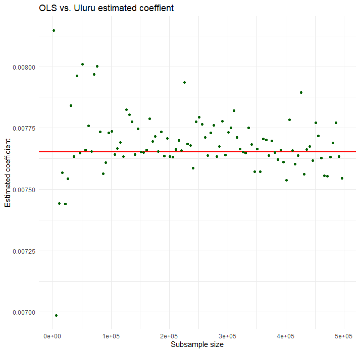

## Elite user Uluru OLS

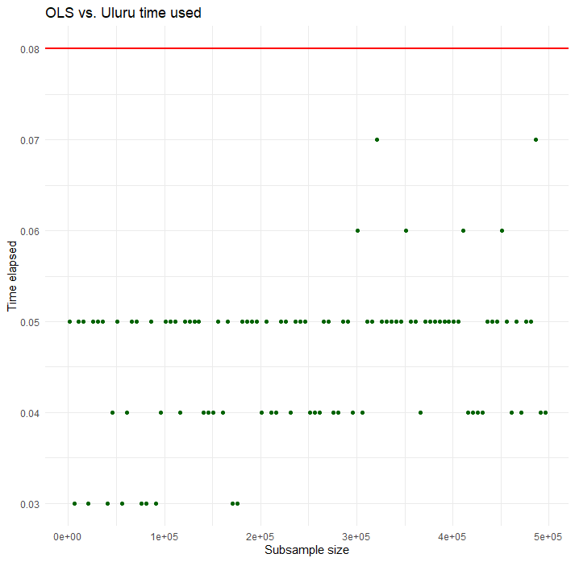

## Restaurant rating analysis

1. Lasso Approach
2. Forward selection

## Lasso Approach

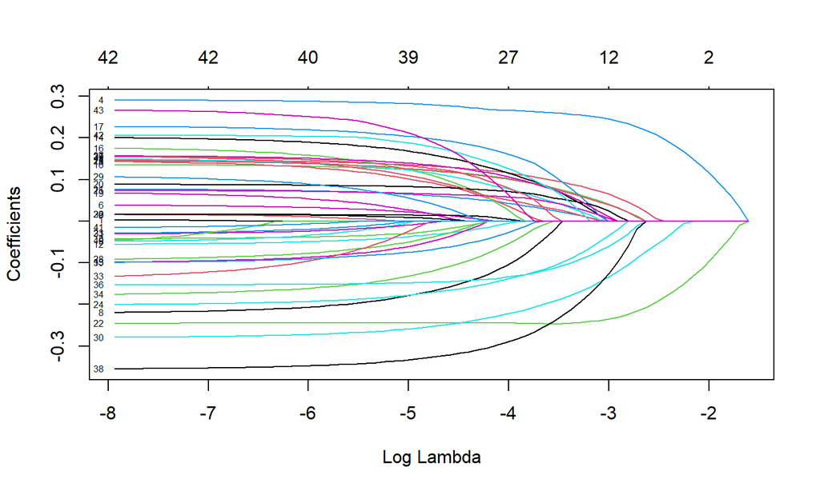

```r
lasso <- glmnet(as.matrix(df_ml[,c(2:44)]), df_ml$stars, alpha = 1)
plot(lasso, xvar = "lambda", label = TRUE)
```

## Lasso Approach

This gives us the two variables that have the *largest beta* and therefore affect the ratings the most in absolute terms.

```
## [1] "attributes.BusinessParking.street"
```

```
## [1] "attributes.HasTV"
```

## Forward Selection

The Forward Selection shows us which variable is the best in explaining the *variance* of restaurant ratings.

```r
forward<-regsubsets(stars~.,data=df ,nvmax=50, method ="forward",
                    intercept = FALSE) #forward selection of variables
overview<-summary(forward)$which #logical matrix showing which variable
                                  #is in what forward model

which(overview[1,]==TRUE)
```

```
## attributes.BusinessAcceptsCreditCards
##                                    10
```

## Forward Selection

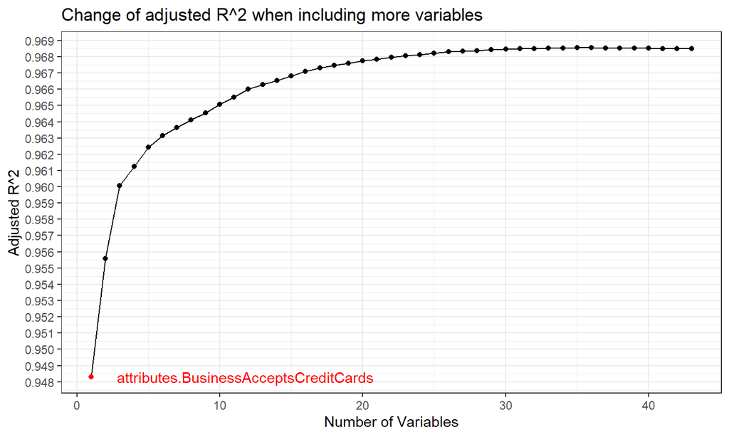